# finalproject

JPR

26 de enero de 2018

## Machine Learning_Coursera

## 1. Course project

**Source of data:** Ugulino, W.; Cardador, D.; Vega, K.; Velloso, E.; Milidiu, R.; Fuks, H. Wearable Computing: Accelerometers’ Data Classification of Body Postures and Movements. Proceedings of 21st Brazilian Symposium on Artificial Intelligence. Advances in Artificial Intelligence - SBIA 2012. In: Lecture Notes in Computer Science. , pp. 52-61. Curitiba, PR: Springer Berlin / Heidelberg, 2012. ISBN 978-3-642-34458-9. DOI: 10.1007/978-3-642-34459-6_6. http://groupware.les.inf.puc-rio.br/har.

**Description:** “The goal of your project is to predict the manner in which they did the exercise. This is the”classe" variable in the training set. You may use any of the other variables to predict with. You should create a report describing how you built your model, how you used cross validation, what you think the expected out of sample error is, and why you made the choices you did. You will also use your prediction model to predict 20 different test cases." (Coursera).

## 2. Preparing data

```r
#Reading data:

data0<-read.csv("https://d396qusza40orc.cloudfront.net/predmachlearn/pml-training.csv", header = T, sep=",")

data.pred<-read.csv("https://d396qusza40orc.cloudfront.net/predmachlearn/pml-testing.csv", header = T, sep=",")


#Exploring variables that have less than 80% of the complete observations

count.nas<-apply(data0,2,fun.nas)
count.nas[count.nas > 0.2*nrow(data0)]
```

```
##       kurtosis_roll_belt      kurtosis_picth_belt        kurtosis_yaw_belt
##                    19216                    19216                    19216
##       skewness_roll_belt     skewness_roll_belt.1        skewness_yaw_belt
##                    19216                    19216                    19216
##            max_roll_belt           max_picth_belt             max_yaw_belt
##                    19216                    19216                    19216
##            min_roll_belt           min_pitch_belt             min_yaw_belt
##                    19216                    19216                    19216
##      amplitude_roll_belt     amplitude_pitch_belt       amplitude_yaw_belt
##                    19216                    19216                    19216
##     var_total_accel_belt            avg_roll_belt         stddev_roll_belt
##                    19216                    19216                    19216
##            var_roll_belt           avg_pitch_belt        stddev_pitch_belt
##                    19216                    19216                    19216
##           var_pitch_belt             avg_yaw_belt          stddev_yaw_belt
##                    19216                    19216                    19216
##             var_yaw_belt            var_accel_arm             avg_roll_arm
##                    19216                    19216                    19216
##          stddev_roll_arm             var_roll_arm            avg_pitch_arm
##                    19216                    19216                    19216
##         stddev_pitch_arm            var_pitch_arm              avg_yaw_arm
##                    19216                    19216                    19216
##           stddev_yaw_arm              var_yaw_arm        kurtosis_roll_arm
##                    19216                    19216                    19216
##       kurtosis_picth_arm         kurtosis_yaw_arm        skewness_roll_arm
##                    19216                    19216                    19216
##       skewness_pitch_arm         skewness_yaw_arm             max_roll_arm
##                    19216                    19216                    19216
##            max_picth_arm              max_yaw_arm             min_roll_arm
##                    19216                    19216                    19216
##            min_pitch_arm              min_yaw_arm       amplitude_roll_arm
##                    19216                    19216                    19216
##      amplitude_pitch_arm        amplitude_yaw_arm   kurtosis_roll_dumbbell
##                    19216                    19216                    19216
##  kurtosis_picth_dumbbell    kurtosis_yaw_dumbbell   skewness_roll_dumbbell
##                    19216                    19216                    19216
##  skewness_pitch_dumbbell    skewness_yaw_dumbbell        max_roll_dumbbell
##                    19216                    19216                    19216
##       max_picth_dumbbell         max_yaw_dumbbell        min_roll_dumbbell
##                    19216                    19216                    19216
```

[output cut: 13 more lines]

```
##                    19216                    19216                    19216
##         max_roll_forearm        max_picth_forearm          max_yaw_forearm
##                    19216                    19216                    19216
##         min_roll_forearm        min_pitch_forearm          min_yaw_forearm
##                    19216                    19216                    19216
##   amplitude_roll_forearm  amplitude_pitch_forearm    amplitude_yaw_forearm
##                    19216                    19216                    19216
##        var_accel_forearm         avg_roll_forearm      stddev_roll_forearm
##                    19216                    19216                    19216
##         var_roll_forearm        avg_pitch_forearm     stddev_pitch_forearm
##                    19216                    19216                    19216
##        var_pitch_forearm          avg_yaw_forearm       stddev_yaw_forearm
##                    19216                    19216                    19216
##          var_yaw_forearm
##                    19216
```

```r
nomb.completes<-names(count.nas[count.nas <= 0.8*nrow(data0)])

#New dataset with more complete observations

data0<-subset(data0,select = nomb.completes)

#Validing nas

count.nas<-apply(data0,2,fun.nas)
count.nas[count.nas>0.2*nrow(data0)]
```

```
## named integer(0)
```

```r
#Final sample remove id variables and non-numerical

data0<-subset(data0, select = c(8:ncol(data0)))

mat.cor<-round(cor(data0[,-53]),2)

diag(mat.cor)=0

#Verifying extreme redundants
which(abs(mat.cor)==1,arr.ind=TRUE)
```

```
##      row col
```

```r
#Possible redundants (heurism):
redu<-which(abs(mat.cor)>= 0.90,arr.ind=TRUE)[,2]

#Next depuration: hightly related with three or more variables:
redu<-table(redu)
redu
```

```
## redu
##  1  2  4  8  9 10 18 19 31 33 46
##  3  1  3  1  3  3  1  1  2  2  2
```

```r
redu<-names(redu[redu>2])
redu<--as.numeric(redu)
data0<-subset(data0, select = redu) #Final sample stage one
```

## 3. Training the models (Cross validation was used according to the task description)

Three methods well be used: Clasification Tree (CT), Linear Discriminant Analysis (LDA) and Random Forest using PCA (RFPCA). The first two using the original variables as predictors, and the last method using principal components as predictors (considering that it consumes a lot of computational time). The task indicates that the **cross validation** must be used.

### 3.1 Classification Tree

```r
#Run in block
#3.1 Classification Tree.
t.ct.ini<-Sys.time()
mod_ct <- train(classe ~ ., data = data0, method = "rpart",
                trControl=trainControl(method = "cv", number = 10))
t.ct.fin<-Sys.time()

dura.ct<-t.ct.fin-t.ct.ini
dura.ct
```

```
## Time difference of 11.59759 secs
```

```r
mod_ct
```

```
## CART
##
## 19622 samples
##    48 predictor
##     5 classes: 'A', 'B', 'C', 'D', 'E'
##
## No pre-processing
## Resampling: Cross-Validated (10 fold)
## Summary of sample sizes: 17662, 17658, 17661, 17658, 17660, 17659, ...
## Resampling results across tuning parameters:
##
##   cp          Accuracy   Kappa
##   0.02983905  0.5090212  0.3594458
##   0.03240279  0.4765587  0.3157292
##   0.06612306  0.4339491  0.2471629
##
## Accuracy was used to select the optimal model using the largest value.
## The final value used for the model was cp = 0.02983905.
```

[figure not shown]

```r
Accuracy<-mean(mod_ct$resample$Accuracy)
Duration<-dura.ct
Methods<-"Class.Tree"

#Plots:
fancyRpartPlot(mod_ct$finalModel)
```

### 3.2 Random Forest with PCA.

```r
#Obtaining the principal components:
pca<-preProcess(data0[,-ncol(data0)], method = "pca", thresh = 0.80)
pca
```

```
## Created from 19622 samples and 48 variables
##
## Pre-processing:
##   - centered (48)
##   - ignored (0)
##   - principal component signal extraction (48)
##   - scaled (48)
##
## PCA needed 13 components to capture 80 percent of the variance
```

```r
xpca<-predict(pca,data0[,-ncol(data0)])
data0.rfpca<-data.frame(xpca,data0$classe)
colnames(data0.rfpca)<-c(names(xpca), "classe")
head(data0.rfpca)
```

```
##        PC1       PC2        PC3       PC4       PC5      PC6        PC7
## 1 2.974292 -4.173946 0.02543571 0.6981822 -1.300229 2.102659 -0.6036510
## 2 2.995545 -4.207998 0.01059507 0.6838513 -1.372163 2.176614 -0.6426112
## 3 3.005057 -4.180400 0.02234630 0.6944082 -1.304551 2.109367 -0.6274456
## 4 2.997514 -4.175405 0.01829516 0.6919186 -1.318815 2.149998 -0.6512505
## 5 3.046917 -4.112798 0.03096100 0.7055147 -1.330028 2.192379 -0.6644948
## 6 3.026668 -4.179147 0.02446835 0.6920656 -1.315030 2.131703 -0.6383816
##         PC8       PC9      PC10       PC11     PC12      PC13 classe
## 1 -2.673255 0.2960633 0.3353628 -0.7488654 1.408646 -2.665904      A
## 2 -2.595677 0.3182818 0.3651738 -0.7317569 1.301884 -2.670773      A
## 3 -2.636733 0.3237700 0.3563015 -0.7391418 1.329539 -2.655822      A
## 4 -2.596223 0.3412436 0.3643975 -0.7477445 1.352860 -2.654289      A
## 5 -2.622692 0.3018274 0.3892109 -0.6923448 1.314432 -2.648957      A
## 6 -2.637910 0.3265775 0.3381554 -0.7265923 1.365050 -2.658734      A
```

```r
#Training the model. Run in block
t.rfpca.ini<-Sys.time()
mod_rfpca <- train(classe ~ ., data = data0.rfpca, method = "rf",
                   trControl=trainControl(method = "cv", number = 10))
t.rfpca.fin<-Sys.time()

dura.rfpca<-t.rfpca.fin-t.rfpca.ini
dura.rfpca
```

```
## Time difference of 10.56516 mins
```

```r
mod_rfpca
```

```
## Random Forest
##
## 19622 samples
##    13 predictor
##     5 classes: 'A', 'B', 'C', 'D', 'E'
##
## No pre-processing
## Resampling: Cross-Validated (10 fold)
## Summary of sample sizes: 17661, 17661, 17661, 17661, 17659, 17659, ...
## Resampling results across tuning parameters:
##
##   mtry  Accuracy   Kappa
##    2    0.9709516  0.9632586
##    7    0.9678428  0.9593237
##   13    0.9613188  0.9510871
##
## Accuracy was used to select the optimal model using the largest value.
## The final value used for the model was mtry = 2.
```

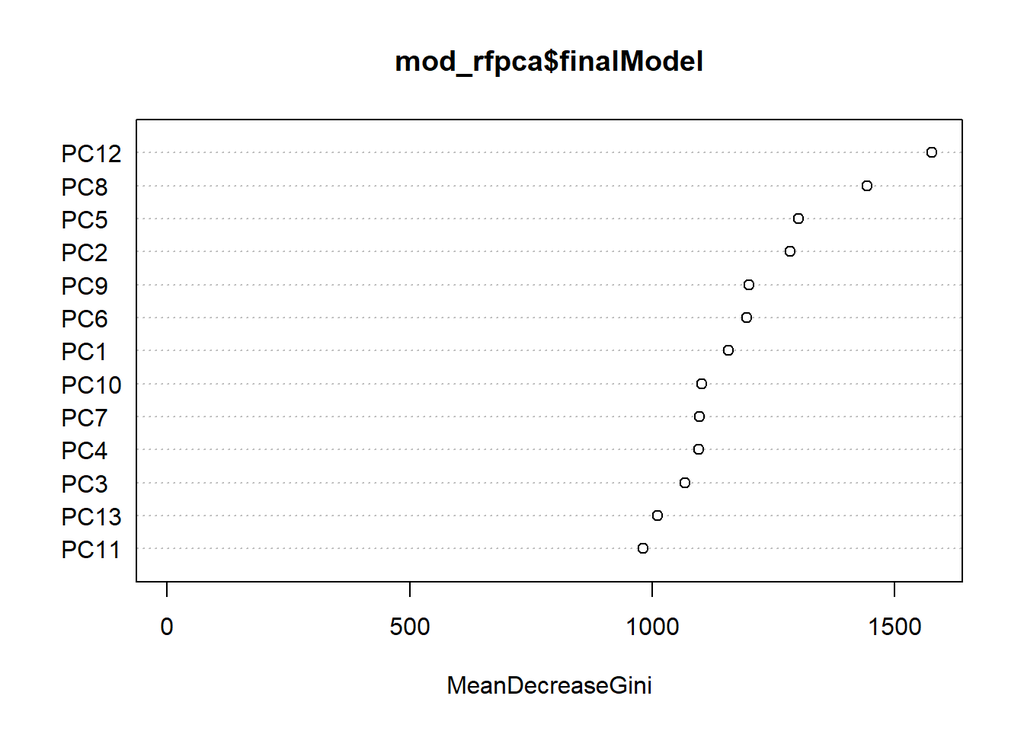

```r
Accuracy<-c(Accuracy,mean(mod_rfpca$resample$Accuracy))
Duration<-c(Duration,dura.rfpca)
Methods<-c(Methods, "Rand.Forest_PCA")

#Variable importance:
varImpPlot(mod_rfpca$finalModel,type=2)
```

# 3.3 Linear Discriminant Analysis.

```r
#Run in block
t.lda.ini<-Sys.time()
mod_lda <- train(classe ~ ., data = data0, method = "lda",
                 trControl=trainControl(method = "cv", number = 10))
t.lda.fin<-Sys.time()

dura.lda<-t.lda.fin-t.lda.ini
dura.lda
```

```
## Time difference of 5.041344 secs
```

```r
mod_lda
```

```
## Linear Discriminant Analysis
##
## 19622 samples
##    48 predictor
##     5 classes: 'A', 'B', 'C', 'D', 'E'
##
## No pre-processing
## Resampling: Cross-Validated (10 fold)
## Summary of sample sizes: 17660, 17660, 17660, 17660, 17659, 17660, ...
## Resampling results:
##
##   Accuracy   Kappa
##   0.6817866  0.5969176
```

```r
Accuracy<-c(Accuracy,mean(mod_lda$resample$Accuracy))
Duration<-c(Duration,dura.lda)
Methods<-c(Methods, "LD.Analysis")
```

## 4. Consolidated results

```r
results<-data.frame(Methods,Accuracy,Duration)

kable(results, digits=2, format = "html")%>%
  kable_styling(bootstrap_options = "striped", full_width = F)
```

| Methods | Accuracy | Duration |
| --- | --- | --- |
| Class.Tree | 0.51 | 11.60 secs |
| Rand.Forest_PCA | 0.97 | 633.91 secs |
| LD.Analysis | 0.68 | 5.04 secs |

**Considering as example only accuracy, RFPCA is used**

## 5.Predictions

**Note**: the specific predictions are not shown.

```r
data.pred.pca<-predict(pca,data.pred)
data.pred.pca<-subset(data.pred.pca, select = c(113:125))
names(data.pred.pca)

predict(mod_rfpca, newdata = data.pred.pca)
```